# Proposal

2025-03-30

## Group Members

Keegan Fitzpatrick, Zixuan Peng, Shikha Asharan, Em McNeil

## Communication

> Communication will occur via Outlook email and an iMessage group chat when not in person.

> In-person meetings will include at least one hour on Thursdays at 4 PM, and if needed, an additional hour on Tuesdays from 3-4 PM may also be used.

> For our code and data, we will use GitHub for version control. Through frequent and active commits, we can ensure that all members are engaged in the project’s progress and that everyone stays up to date with the latest changes.

## Question of Interest

The questions we aim to explore with this dataset are as follows: - Whether there is a positive linear relationship between Trump vote share and the hate crime rate among the sample of U.S. states. - Whether the social demographic structure of a state (e.g., high school graduation rate, proportion of non-citizens, proportion of white population in poverty) has a positive linear relationship with the frequency of hate crimes. - Whether a state’s economic condition (e.g., income level, unemployment rate) has a positive linear relationship with the frequency of hate crimes. - Which variables are the most important predictors of hate crime rates? Between social structure and economic condition, which has a greater influence?

## Data and Description

> Source: https://github.com/fivethirtyeight/data/blob/master/hate-crimes/README.md

> Data Sourcs:
- Hate crime rate by state - SPLC or FBI
- Share trump vote: United states elections project U-Florida
- Median Income- Census
- Other columns- Kaiser foundation

> Note: github links to SPLC and FBI data do not work anymore.

> SPLC hate crime data for 2016 can be found here: https://www.splcenter.org/hate-map/?hm_year=2023&hm_state=WI FBI hate crime data 2016 can be found here (tables 12 and 13): https://ucr.fbi.gov/hate-crime/2016/topic-pages/jurisdiction#:~:text=Jurisdictional%20data%20provide%20aggregate%20state,11.6%20percent)%20reported%206%2C121%20incidents.

> The merged datasets compiled by 538 was gathered for an article discussing the relationsip between income inequality (gini index) and hate crime rate by state. The dataset we will use is merged from multiple other datasets by various governmental and non-profit agences. For the variables we are most interested in the gathering process goes as following: Median income is simply calculated from U.S. census data. Share of trump vote is calculated from 2016 election results for each state and is simply the #trump_votes/#votes for each state. SPLC gets their hate crime data partially from voluntary reporting by agencies and also by personal testimonies and victim surveys. FBI gathers only from voluntary participation by police agencies and thus their estimates are lower.

> The original 538 article can be found here: https://fivethirtyeight.com/features/higher-rates-of-hate-crimes-are-tied-to-income-inequality/

> The data is a cross section of 2016 of 50 states + DC where each observation is a state or DC. number of rows is 51 + header and number of columns is 12.

> Key variables of interest:
- share_voters_voted_trump - used to explore whether Trump vote share is positively associated with hate crime rates across states (Question 1).
- hate_crimes_per_100k_splc and avg_hatecrimes_per_100k_fbi - both are outcome variables representing the frequency of hate crimes and will be used to evaluate all four questions.
- share_population_with_high_school_degree, share_non_citizen, share_white_poverty, and share_non_white - used to measure the social structure of each state and investigate whether it has a relationship with hate crime frequency (Question 2).
- median_household_income, share_unemployed_seasonal, and gini_index - used to evaluate the state’s economic condition and its potential influence on hate crimes (Question 3).
- All the above predictor variables will also be used in a modeling framework (e.g., regression) to determine which variables are the strongest predictors of hate crimes, and to compare the relative influence of social structure versus economic conditions (Question 4).

> Single row meanings:

> Each row in the dataset represents one U.S. state (or the District of Columbia). It contains aggregated data that describe various social, economic, demographic, political, and crime-related indicators for that specific state.

```r
#edit the function below with personalized file path
hatecrimes <- read_csv("hate_crimes.csv")
hatecrimes
```

```
## # A tibble: 51 × 12
##    state    median_household_inc…¹ share_unemployed_sea…² share_population_in_…³
##    <chr>                     <dbl>                  <dbl>                  <dbl>
##  1 Alabama                   42278                  0.06                    0.64
##  2 Alaska                    67629                  0.064                   0.63
##  3 Arizona                   49254                  0.063                   0.9
##  4 Arkansas                  44922                  0.052                   0.69
##  5 Califor…                  60487                  0.059                   0.97
##  6 Colorado                  60940                  0.04                    0.8
##  7 Connect…                  70161                  0.052                   0.94
##  8 Delaware                  57522                  0.049                   0.9
##  9 Distric…                  68277                  0.067                   1
## 10 Florida                   46140                  0.052                   0.96
## # ℹ 41 more rows
## # ℹ abbreviated names: ¹median_household_income, ²share_unemployed_seasonal,
## #   ³share_population_in_metro_areas
## # ℹ 8 more variables: share_population_with_high_school_degree <dbl>,
## #   share_non_citizen <dbl>, share_white_poverty <dbl>, gini_index <dbl>,
## #   share_non_white <dbl>, share_voters_voted_trump <dbl>,
## #   hate_crimes_per_100k_splc <dbl>, avg_hatecrimes_per_100k_fbi <dbl>
```

## Graph Outline

#### Question 1:

> We will provide a scatter plot of hate_crime_rate vs trump_vote_share and put a line of best fit through the data. Will include labs and a legend if necessary. Below is a very rough draft of a graph we will show.

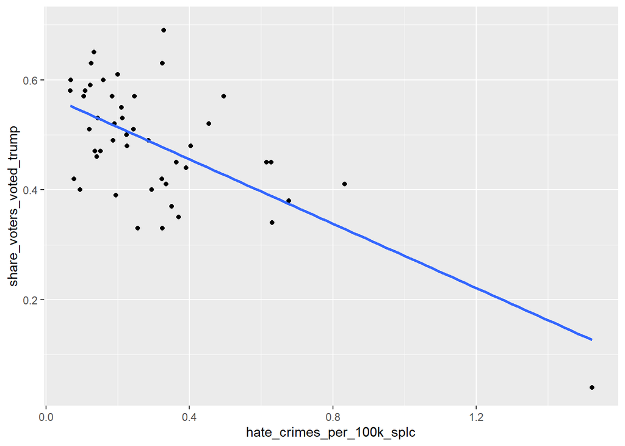

```r
hatecrimes %>% ggplot(aes(hate_crimes_per_100k_splc, share_voters_voted_trump)) + geom_point() +
  geom_smooth(method = "lm", se = F)
```

#### Question 2:

> We will provide three separate scatter plots of hate_crime_rate vs each of the following variables:
- share_population_with_high_school_degree
- share_non_citizen
- share_white_poverty

For each plot, we will add a line of best fit to visually assess any linear trend. Each graph will include appropriate axis labels, a descriptive title, and a legend if necessary.

#### Question 3:

> We will provide three separate scatter plots of hate_crime_rate vs each of the following variables:
- median_household_income
- share_unemployed_seasonal
- gini_index

For each plot, we will add a line of best fit to visually assess any linear trend. Each graph will include appropriate axis labels, a descriptive title, and a legend if necessary.

#### Question 4:

> We will create a graph that uses different colors to represent the linear relationship between each variable and the hate crime rate, in order to identify the most important predictors.

## Inference Method

We will be using simple linear regression of hate_crime_rate on other variables specified for all mentioned questions.